# 2501report_ShenHongshan

Shen Hongshan

2025-11-20

# Predicting Mental Health Treatment Needs Based on Workplace Factors and Demographic Characteristics

### Author: Shen Hongshan (3036290936)

### Data source: [Kaggle Mental Health in Tech Survey](https://www.kaggle.com/datasets/osmi/mental-health-in-tech-survey/data)

## **1. Introduction**

### 1.1 Background

Mental health issues in workplace environments represent a significant public health concern with substantial economic and social consequences. Early identification of individuals who need mental health support can facilitate timely intervention, reduce workplace productivity loss, and improve overall well-being. This project addresses the critical need for data-driven approaches to mental health screening in professional settings, particularly in high-pressure sectors like technology.

This project, analyzes the OSMI Mental Health in Tech Survey dataset from Kaggle to model how workplace conditions and demographic factors are associated with issue. The dataset contains survey responses to workplace, demographic and mental health questions, providing rich information for data-driven analysis of this spublic health issue.

### 1.2 Data science question

The analysis focuses on two primary research questions:

- **What are the most significant demographics and workplace features associated with employees seeking mental health treatment?**
- **Based on these associations, what targeted interventions can employers prioritize?**

### 1.3 Methodological Challenges

Challenges are anticipated in this analysis, including handling **class imbalance** in the target variable, managing missing survey data, and addressing potential **response bias**.The subjective nature of self-reported mental health data may introduce measurement noise, requiring careful data cleaning and validation approaches.

## **2. Data Loading & Cleaning**

### 2.1 Data loading

```r
library(tidyverse)
library(readr)
library(dplyr)
library(ggplot2)
library(knitr)
library(caret)
library(broom)
library(car)  # for VIF
library(pROC)
library(patchwork)

# Read the dataset (make sure 'survey.csv' is in the same folder)
survey_data <- read_csv("survey.csv")

# Overview: dimensions and column names
cat("Dataset dimensions:", dim(survey_data), "\n")
```

```
## Dataset dimensions: 1259 27
```

```r
cat("Column names:\n")
```

```
## Column names:
```

```r
names(survey_data)
```

```
##  [1] "Timestamp"                 "Age"
##  [3] "Gender"                    "Country"
##  [5] "state"                     "self_employed"
##  [7] "family_history"            "treatment"
##  [9] "work_interfere"            "no_employees"
## [11] "remote_work"               "tech_company"
## [13] "benefits"                  "care_options"
## [15] "wellness_program"          "seek_help"
## [17] "anonymity"                 "leave"
## [19] "mental_health_consequence" "phys_health_consequence"
## [21] "coworkers"                 "supervisor"
## [23] "mental_health_interview"   "phys_health_interview"
## [25] "mental_vs_physical"        "obs_consequence"
## [27] "comments"
```

### 2.2 Handle Missing Values, drop Irrelevant biased sampled variables

- Check the number of missing value for each variable, delete those with too many NAs: comments, state
- delete irrelevant variable for analysis: Timestamp
- delete biased sampled variable: Country (60% from USA, most countries which have only 1 respondents)

```r
# Missing value summary
data.frame(Missing_data=sort(colSums(is.na(survey_data)),decreasing=TRUE))
```

```
##                           Missing_data
## comments                          1096
## state                              515
## work_interfere                     264
## self_employed                       18
## Timestamp                            0
## Age                                  0
## Gender                               0
## Country                              0
## family_history                       0
## treatment                            0
## no_employees                         0
## remote_work                          0
## tech_company                         0
## benefits                             0
## care_options                         0
## wellness_program                     0
## seek_help                            0
## anonymity                            0
## leave                                0
## mental_health_consequence            0
## phys_health_consequence              0
## coworkers                            0
## supervisor                           0
## mental_health_interview              0
## phys_health_interview                0
## mental_vs_physical                   0
## obs_consequence                      0
```

```r
# Drop columns with too many NAs or irrelevant for analysis (comments, Timestamp, state)
survey_clean0 <- survey_data |>
  select(-Timestamp, -Country, -comments, -state)

cat("Columns left after removal:", names(survey_clean0))
```

```
## Columns left after removal: Age Gender self_employed family_history treatment work_interfere no_employees remote_work tech_company benefits care_options wellness_program seek_help anonymity leave mental_health_consequence phys_health_consequence coworkers supervisor mental_health_interview phys_h…
```

### 2.3 Standardize Variables

- Convert **Gender** variable into standard level: Male/ Female/ Transgender/Non-binary/Others
- Remove unrealistic **Age** input, only maintain age within 18~100 years old
- sort the levels for better visualization latter: work_interfere(4 level), leave(5 level), no_employees(6 level)

```r
survey_clean0 <- survey_clean0 |>
  mutate(
    # Gender standardization
    Gender = case_when(
      str_detect(tolower(Gender), "^m|^male|^man|^maile|^make|^mal$|^male-ish|^guy") ~ "Male",
      str_detect(tolower(Gender), "^f|^female|^woman|^femaile|^femake|^fem") ~ "Female",
      TRUE ~ "Transgender/Non-binary/Others"
    ),
    # Convert character columns to factors
    across(where(is.character), as.factor)
  )

# Handle age outliers
survey_clean0 <- survey_clean0 |>
  mutate(
    Age = case_when(
      Age < 18 ~ NA,    # Remove unrealistic ages
      Age > 100 ~ NA,
      TRUE ~ Age
    )
  ) |>
  filter(!is.na(Age))  # Remove rows with invalid ages

#sort the levels of variables
survey_clean0$work_interfere <-
  factor(survey_clean0$work_interfere,levels = c("Never", "Rarely", "Sometimes", "Often"))
survey_clean0$leave <-
  factor(survey_clean0$leave,levels = c("Very difficult","Somewhat difficult","Somewhat easy","Very easy","Don't know"))
survey_clean0$no_employees <-
  factor(survey_clean0$no_employees,levels = c("1-5", "6-25", "26-100", "100-500", "500-1000", "More than 1000"))
```

### 2.3 Combine variables with similar meaning

- The variables “benefits,” “care_options,” “wellness_program,” and “seek_help” each measure a different facet of employers’ support for mental health. So, they can be consolidated into a single variable, “mental_care,” with a binary (Yes/No) level.

```r
survey_clean <- survey_clean0|>
  mutate(mental_care=if_any(c(benefits, care_options, wellness_program, seek_help), ~ . == "Yes"))

survey_clean<- survey_clean|>
  select(-benefits, -care_options, -wellness_program, -seek_help)
```

## **3. Exploratory Data Analysis & Visualization**

### 3.1 Target Variable Check

- The target variable **“treatment”** indicates whether an employee is currently seeking treatment for a mental health condition.
- **49.48%** report **No** and **50.52%** report **Yes**, which underscoring the significance of mental health conditions in the workplace.

```r
#Distribution of treatment status
as.data.frame(table(survey_clean$treatment))
```

```
##   Var1 Freq
## 1   No  619
## 2  Yes  632
```

```r
#Proportion table
as.data.frame(prop.table(table(survey_clean$treatment)))
```

```
##   Var1      Freq
## 1   No 0.4948042
## 2  Yes 0.5051958
```

### 3.2 Demographic Overview

- sample is skewed to male by Gender, thus it is important to notice the potential bias caused by this during analysis

```r
demographic_summary <- survey_clean %>%
  summarise(
    n = n(),
    avg_age = mean(Age, na.rm = TRUE),
    male_pct = round(mean(Gender == "Male")*100,1),
    female_pct = round(mean(Gender == "Female")*100,1),
    treatment_rate = round(mean(treatment == "Yes")*100,1)
  )
#Sample Demographic Summary
demographic_summary
```

```
## # A tibble: 1 × 5
##       n avg_age male_pct female_pct treatment_rate
##   <int>   <dbl>    <dbl>      <dbl>          <dbl>
## 1  1251    32.1     78.7       19.8           50.5
```

### 3.3 Key Visualizations

- Treatment rate by Age, Gender, family_history, work_interference, mental_care, tech_company

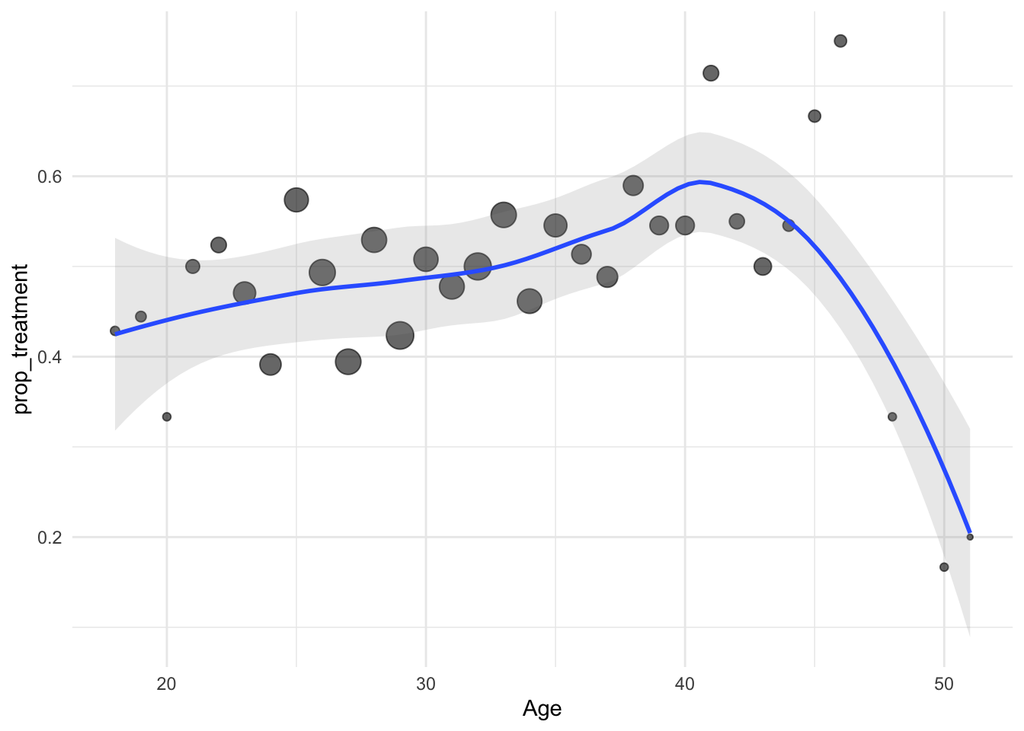

```r
# prepare Age-treatment information for visualization
Age_summary<-survey_clean|>
  group_by(Age)|>
  summarise(
    n_total = n(),
    n_treatment = sum(treatment == "Yes", na.rm = TRUE),
    prop_treatment = n_treatment / n_total,
    .groups = "drop"
  )|>
  filter(n_total>=5)
#
Age_visualization<-ggplot(Age_summary , aes(x = Age, y = prop_treatment, size = n_total)) +
  geom_point(alpha = 0.6) +
  geom_smooth(alpha = 0.2)+
  theme_minimal()+
  theme(legend.position = "none")

Age_visualization
```

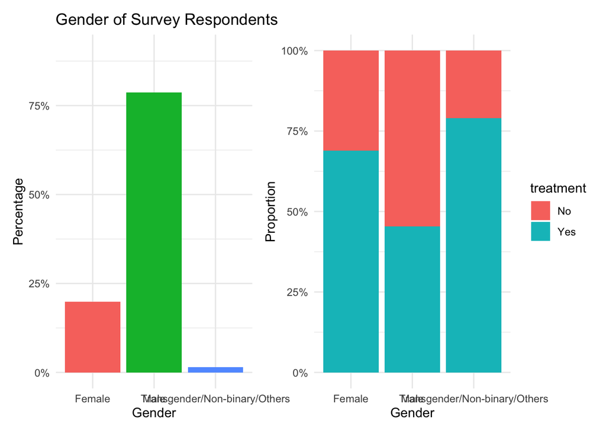

```r
# proportion of answers for different features
feature_prop <- function(data, var, var_name) {
  # Use tidy evaluation with {{var}}
  percentage_data <- data |>
    count({{var}}) |>
    mutate(Percentage = n / sum(n))

  # Create plot
  ggplot(percentage_data, aes(x = {{var}}, y = Percentage, fill = {{var}})) +
    geom_bar(stat = "identity") +
    scale_y_continuous(labels = scales::percent_format(),
                       limits = c(0, max(percentage_data$Percentage) * 1.15)) +
    labs(title = paste(var_name, "of Survey Respondents"),
         x = var_name, y = "Percentage") +
    theme_minimal() +
    theme(legend.position = "none")
}

# Treatment rate by feature (function) - FIXED to use tidy evaluation
treatment_prop <- function(data, feature, feature_name) {
  ggplot(data, aes(x = {{feature}}, fill = treatment)) +
    geom_bar(position = "fill") +
    labs(y = "Proportion", x = feature_name) +
    scale_y_continuous(labels = scales::percent) +
    theme_minimal()
}

#plots for each feature
feature_prop(survey_clean, Gender, "Gender")+
  treatment_prop(survey_clean, Gender, "Gender")
```

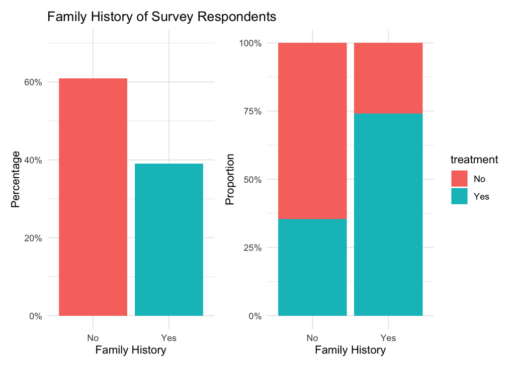

```r
feature_prop(survey_clean, family_history, "Family History")+
  treatment_prop(survey_clean, family_history, "Family History")
```

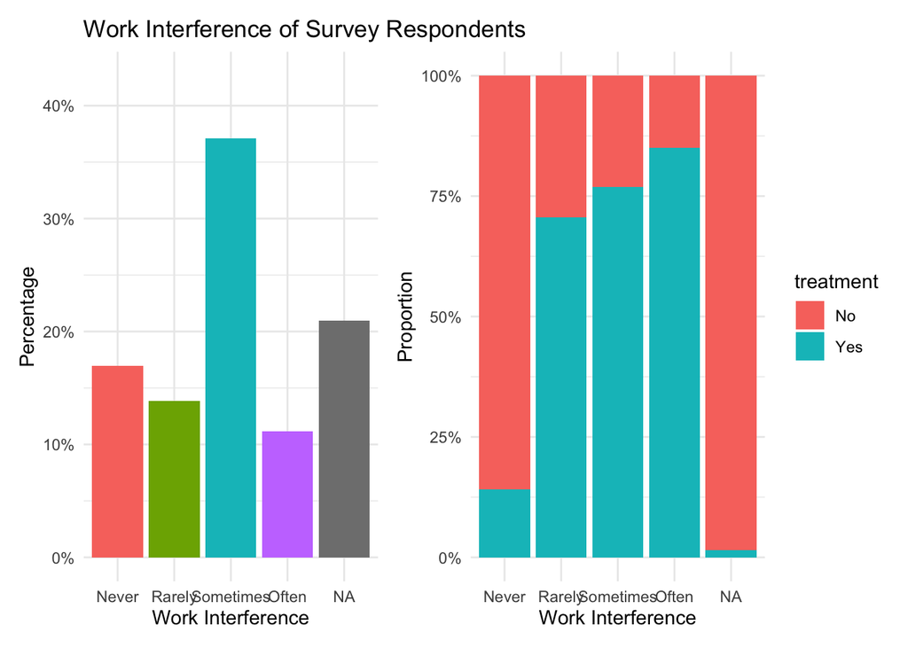

```r
feature_prop(survey_clean, work_interfere, "Work Interference")+
  treatment_prop(survey_clean, work_interfere, "Work Interference")
```

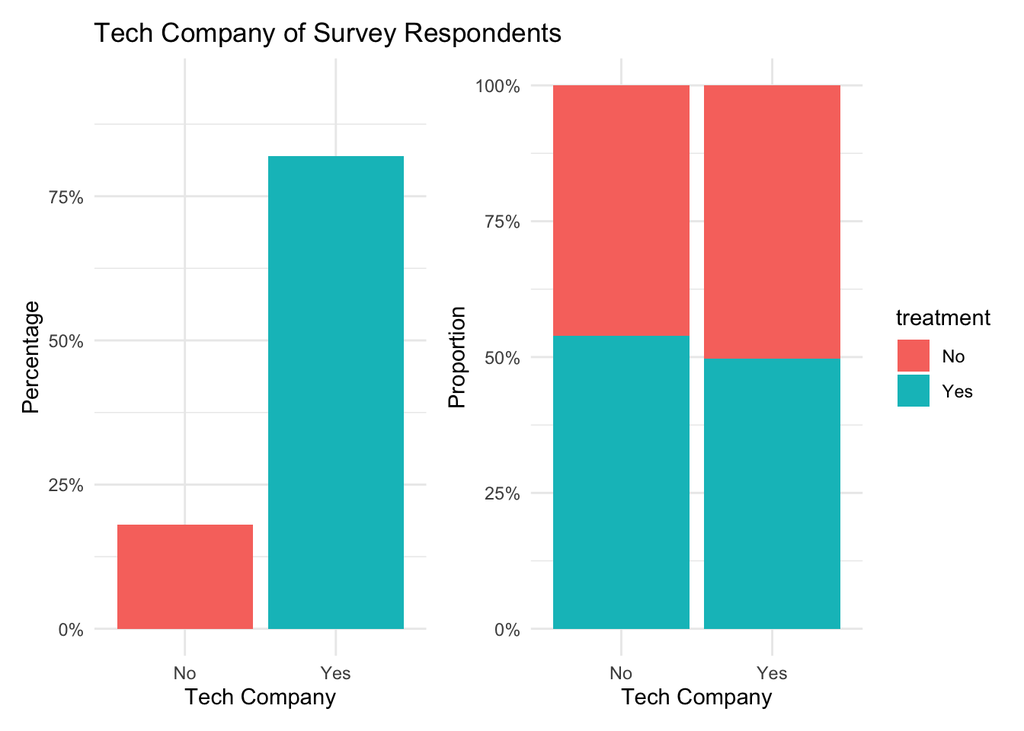

```r
feature_prop(survey_clean, tech_company, "Tech Company")+
  treatment_prop(survey_clean, tech_company, "Tech Company")
```

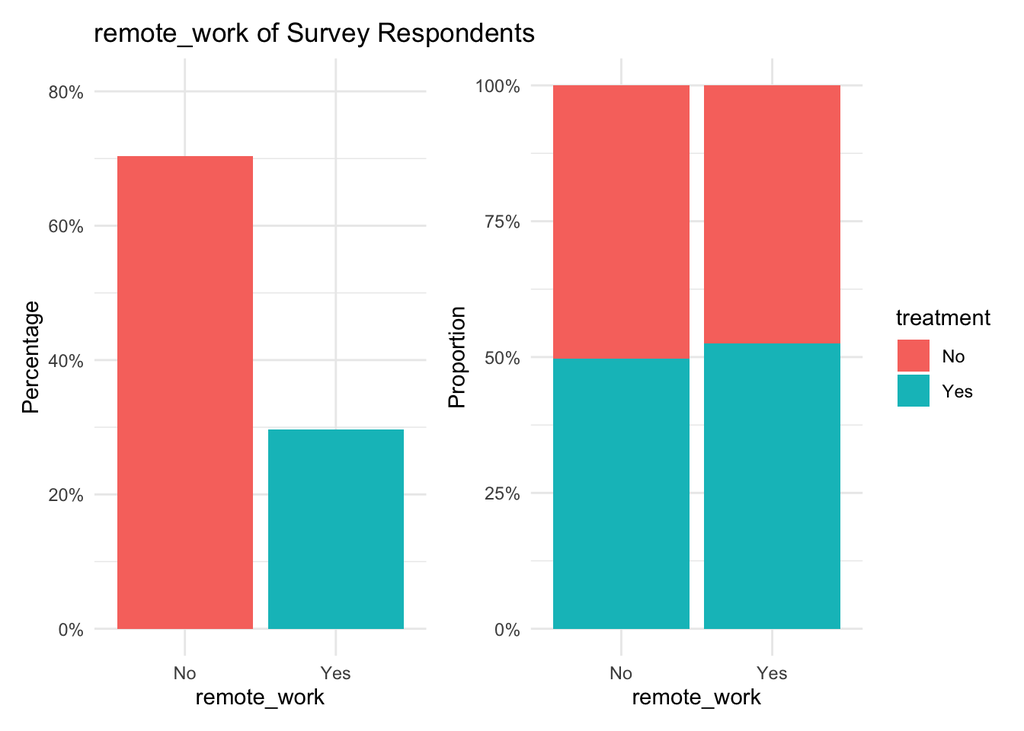

```r
feature_prop(survey_clean, remote_work, "remote_work")+
  treatment_prop(survey_clean, remote_work, "remote_work")
```

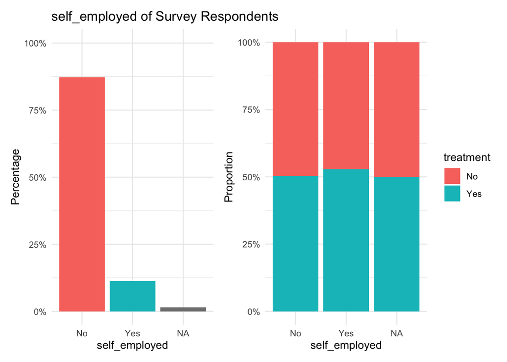

```r
feature_prop(survey_clean, self_employed, "self_employed")+
  treatment_prop(survey_clean, self_employed, "self_employed")
```

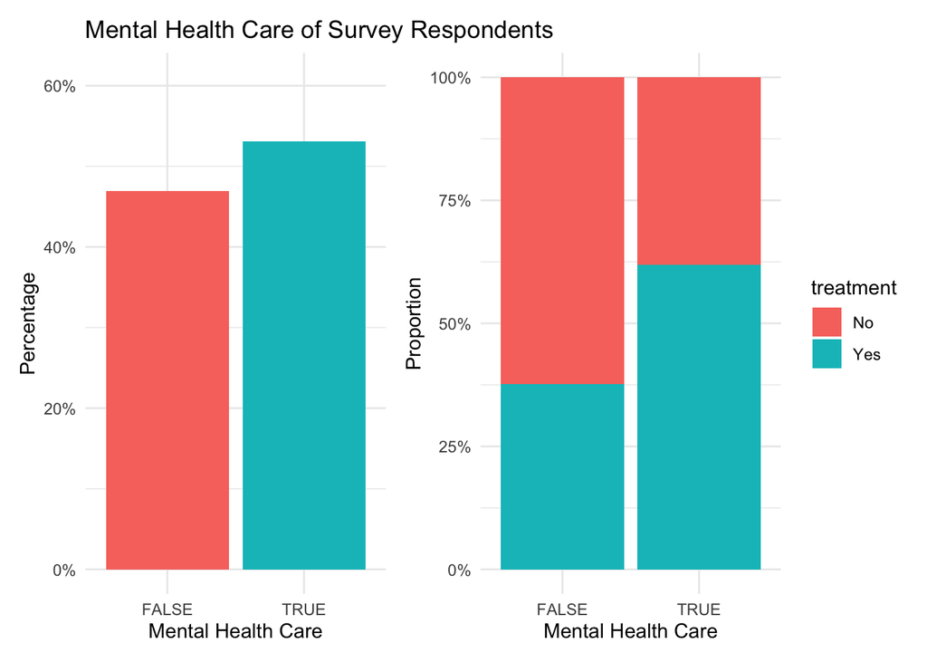

```r
#company resourses
feature_prop(survey_clean, mental_care, "Mental Health Care")+
  treatment_prop(survey_clean, mental_care, "Mental Health Care")
```

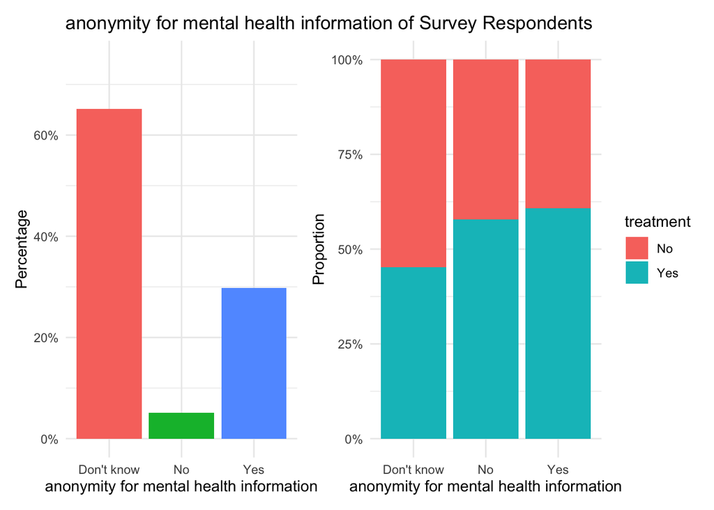

```r
feature_prop(survey_clean, anonymity, "anonymity for mental health information")+
  treatment_prop(survey_clean, anonymity, "anonymity for mental health information")
```

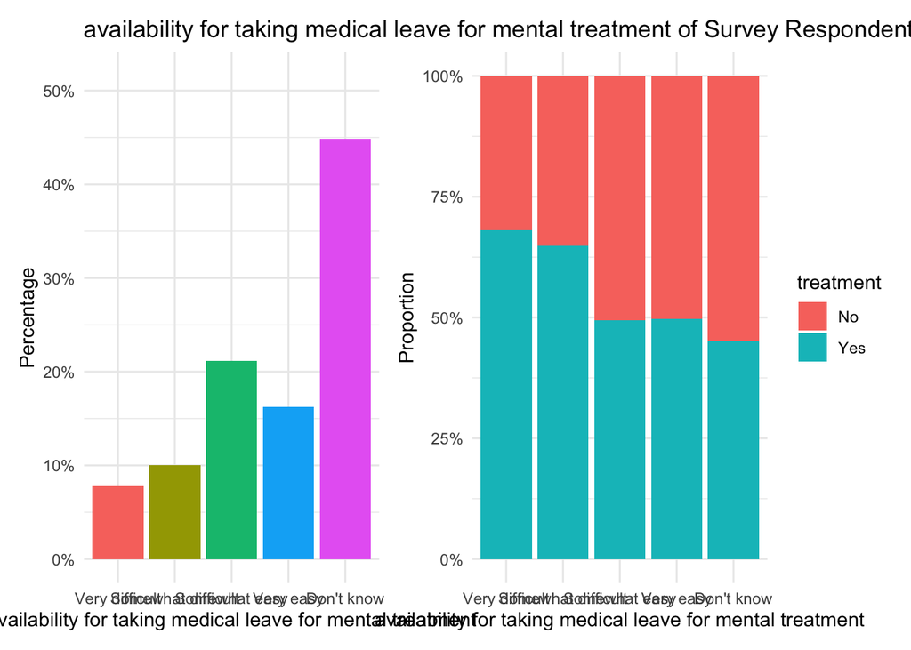

```r
feature_prop(survey_clean, leave, "availability for taking medical leave for mental treatment")+
  treatment_prop(survey_clean, leave, "availability for taking medical leave for mental treatment")
```

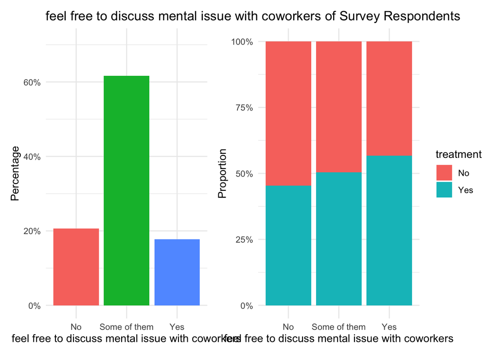

```r
feature_prop(survey_clean, coworkers,"feel free to discuss mental issue with coworkers")+
  treatment_prop(survey_clean,coworkers,"feel free to discuss mental issue with coworkers")
```

## **4. Modelling & Statistical Analysis**

### 4.1 Prepare Data for Modelling

```r
# Create binary target variable
survey_model <- survey_clean %>%
  mutate(
    treatment_binary = ifelse(treatment == "Yes", 1, 0)
  )

# Select key predictors as per project proposal
predictors <- c(
  "Age", "Gender", "family_history",
  "work_interfere", "no_employees", "remote_work", "tech_company",
  "mental_care",
  "anonymity", "leave",
  "mental_health_consequence", "phys_health_consequence",
  "coworkers", "supervisor", "mental_health_interview",
  "mental_vs_physical", "obs_consequence"
)

model_data <- survey_model |>
  select(all_of(c("treatment_binary", predictors))) |>
  na.omit() ##删除数据缺失行

head(model_data)
```

```
## # A tibble: 6 × 18
##   treatment_binary   Age Gender family_history work_interfere no_employees
##              <dbl> <dbl> <fct>  <fct>          <fct>          <fct>
## 1                1    37 Female No             Often          6-25
## 2                0    44 Male   No             Rarely         More than 1000
## 3                0    32 Male   No             Rarely         6-25
## 4                1    31 Male   Yes            Often          26-100
## 5                0    31 Male   No             Never          100-500
## 6                0    33 Male   Yes            Sometimes      6-25
## # ℹ 12 more variables: remote_work <fct>, tech_company <fct>,
## #   mental_care <lgl>, anonymity <fct>, leave <fct>,
## #   mental_health_consequence <fct>, phys_health_consequence <fct>,
## #   coworkers <fct>, supervisor <fct>, mental_health_interview <fct>,
## #   mental_vs_physical <fct>, obs_consequence <fct>
```

### 4.2 Split Data: Train/Test

```r
set.seed(42)
train_idx <- createDataPartition(model_data$treatment_binary, p=0.7, list=FALSE)
train_data <- model_data[train_idx, ]
test_data <- model_data[-train_idx, ]

cat("Training set size:", nrow(train_data), "\n")
```

```
## Training set size: 693
```

```r
cat("Test set size:", nrow(test_data), "\n")
```

```
## Test set size: 296
```

### 4.3 Logistic Regression Model

target variable & feature variable are both discrete, most of them with only 2~3 levels. So, we can not use linear regression, but logistic regression to explore what are the significant features associated with our target value “treatment”

```r
logit_model <- glm(treatment_binary ~ ., data=train_data, family="binomial")

cat("Model summary (logistic regression):\n")
```

```
## Model summary (logistic regression):
```

```r
summary(logit_model)
```

```
##
## Call:
## glm(formula = treatment_binary ~ ., family = "binomial", data = train_data)
##
## Coefficients:
##                                     Estimate Std. Error z value Pr(>|z|)
## (Intercept)                         -3.05835    0.89832  -3.405 0.000663 ***
## Age                                  0.03011    0.01450   2.077 0.037837 *
## GenderMale                          -0.79747    0.28035  -2.845 0.004448 **
## GenderTransgender/Non-binary/Others  0.19497    0.91680   0.213 0.831584
## family_historyYes                    1.08318    0.21276   5.091 3.56e-07 ***
## work_interfereRarely                 2.11481    0.32405   6.526 6.75e-11 ***
## work_interfereSometimes              2.68910    0.29640   9.072  < 2e-16 ***
## work_interfereOften                  2.88780    0.38183   7.563 3.94e-14 ***
## no_employees6-25                     0.36963    0.35319   1.047 0.295310
## no_employees26-100                   0.65790    0.36357   1.810 0.070367 .
## no_employees100-500                  0.70573    0.43058   1.639 0.101205
## no_employees500-1000                 0.85216    0.60058   1.419 0.155930
## no_employeesMore than 1000           0.26291    0.37641   0.698 0.484892
## remote_workYes                       0.01822    0.23748   0.077 0.938838
## tech_companyYes                     -0.06577    0.28103  -0.234 0.814958
## mental_careTRUE                      0.57800    0.22927   2.521 0.011699 *
## anonymityNo                         -0.01578    0.45670  -0.035 0.972441
## anonymityYes                         0.47029    0.26063   1.804 0.071163 .
## leaveSomewhat difficult             -0.27922    0.47677  -0.586 0.558115
## leaveSomewhat easy                  -0.72958    0.44131  -1.653 0.098288 .
## leaveVery easy                      -0.32236    0.48513  -0.664 0.506384
## leaveDon't know                     -0.51625    0.41638  -1.240 0.215023
## mental_health_consequenceNo         -0.25477    0.28531  -0.893 0.371878
## mental_health_consequenceYes        -0.11745    0.30379  -0.387 0.699050
## phys_health_consequenceNo            0.17988    0.27915   0.644 0.519329
## phys_health_consequenceYes          -0.61063    0.48552  -1.258 0.208507
## coworkersSome of them                0.44016    0.28520   1.543 0.122747
## coworkersYes                         1.09031    0.42254   2.580 0.009870 **
## supervisorSome of them              -0.25823    0.29497  -0.875 0.381345
## supervisorYes                       -0.32457    0.33779  -0.961 0.336621
## mental_health_interviewNo            0.31513    0.31713   0.994 0.320365
## mental_health_interviewYes           0.16143    0.72359   0.223 0.823457
## mental_vs_physicalNo                -0.04933    0.26430  -0.187 0.851929
## mental_vs_physicalYes                0.04360    0.29458   0.148 0.882340
## obs_consequenceYes                   0.23140    0.30289   0.764 0.444886
## ---
## Signif. codes:  0 '***' 0.001 '**' 0.01 '*' 0.05 '.' 0.1 ' ' 1
##
## (Dispersion parameter for binomial family taken to be 1)
##
##     Null deviance: 903.92  on 692  degrees of freedom
## Residual deviance: 622.27  on 658  degrees of freedom
## AIC: 692.27
##
## Number of Fisher Scoring iterations: 5
```

#### Predictors sorted by p-value (significance)

```r
significant_predictors <- broom::tidy(logit_model) |>
  arrange(p.value)
significant_predictors
```

```
## # A tibble: 35 × 5
##    term                    estimate std.error statistic  p.value
##    <chr>                      <dbl>     <dbl>     <dbl>    <dbl>
##  1 work_interfereSometimes   2.69      0.296       9.07 1.16e-19
##  2 work_interfereOften       2.89      0.382       7.56 3.94e-14
##  3 work_interfereRarely      2.11      0.324       6.53 6.75e-11
##  4 family_historyYes         1.08      0.213       5.09 3.56e- 7
##  5 (Intercept)              -3.06      0.898      -3.40 6.63e- 4
##  6 GenderMale               -0.797     0.280      -2.84 4.45e- 3
##  7 coworkersYes              1.09      0.423       2.58 9.87e- 3
##  8 mental_careTRUE           0.578     0.229       2.52 1.17e- 2
##  9 Age                       0.0301    0.0145      2.08 3.78e- 2
## 10 no_employees26-100        0.658     0.364       1.81 7.04e- 2
## # ℹ 25 more rows
```

#### Feature Importance Plot

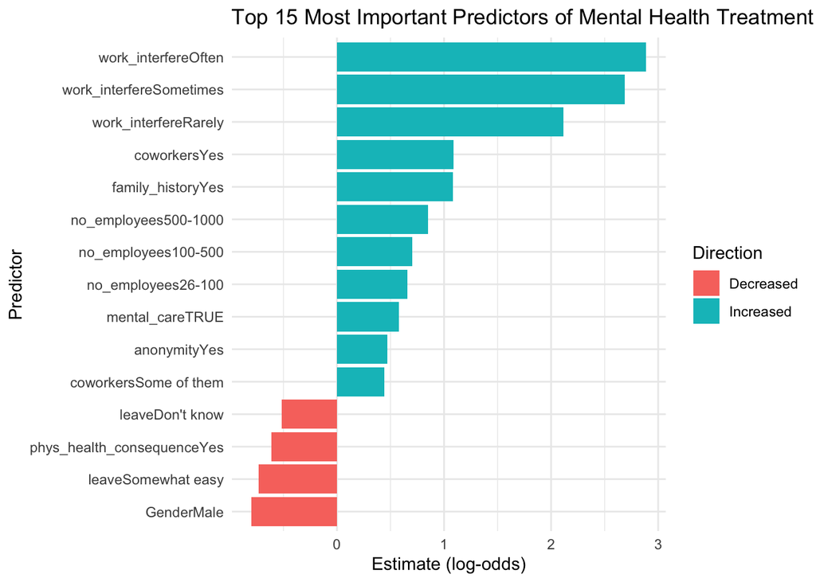

```r
feature_importance <- broom::tidy(logit_model) %>%
  filter(term != "(Intercept)") %>%
  mutate(odds_ratio=exp(estimate),
         direction=ifelse(estimate>0,"Increased","Decreased")) %>%
  arrange(desc(abs(estimate)))
top_features <- feature_importance %>% head(15)

ggplot(top_features, aes(x=reorder(term, estimate), y=estimate, fill=direction)) +
  geom_col() +
  coord_flip() +
  labs(title="Top 15 Most Important Predictors of Mental Health Treatment Need",
       x="Predictor", y="Estimate (log-odds)", fill="Direction") +
  theme_minimal()
```

### 4.4 Insights

- **Work interference** is the single strongest signal: respondents saying their mental health often interferes with work are far more likely to be in treatment. This supports screening based on self‑reported work interference.
- **Family history** and **coworker openness** are also meaningful predictors. Family history increases risk, and feeling free to discuss with coworkers is positively associated with being in treatment, reflecting greater willingness to seek help or workplaces where issues are more openly discussed.
- Company provisions (**mental_care TRUE, anonymity TRUE**) are positively associated with treatment.This can mean:
  - access to care increases uptake
  - companies experiencing higher demand put programs in place (reverse causality)
  - confounding by unmeasured factors.
- Male gender is associated with lower odds of being in treatment. That likely reflects **differing help‑seeking behavior**, **not necessarily lower need.**

### 5. Model Evaluation

#### ROC Curve

- ROC plots **sensitivity (true positive rate)** vs **1 − specificity (false positive rate)** over thresholds. The curve is **well above the diagonal:** model discriminates much better than random.
- **AUC = 0.8476716** indicates good ranking/discrimination: the model usually gives higher predicted probabilities to respondents who are actually in treatment than to those who are not.

```r
test_data$predicted_prob <- predict(logit_model, newdata=test_data, type="response")
test_data$predicted_class <- ifelse(test_data$predicted_prob > 0.5, 1, 0)

test_conf <- confusionMatrix(as.factor(test_data$predicted_class), as.factor(test_data$treatment_binary))
print(test_conf)
```

```
## Confusion Matrix and Statistics
##
##           Reference
## Prediction   0   1
##          0  69  15
##          1  44 168
##
##                Accuracy : 0.8007
##                  95% CI : (0.7506, 0.8447)
##     No Information Rate : 0.6182
##     P-Value [Acc > NIR] : 1.045e-11
##
##                   Kappa : 0.5559
##
##  Mcnemar's Test P-Value : 0.0002671
##
##             Sensitivity : 0.6106
##             Specificity : 0.9180
##          Pos Pred Value : 0.8214
##          Neg Pred Value : 0.7925
##              Prevalence : 0.3818
##          Detection Rate : 0.2331
##    Detection Prevalence : 0.2838
##       Balanced Accuracy : 0.7643
##
##        'Positive' Class : 0
##
```

```r
roc_curve <- roc(test_data$treatment_binary, test_data$predicted_prob)
cat("AUC on test:", auc(roc_curve), "\n")
```

```
## AUC on test: 0.8476716
```

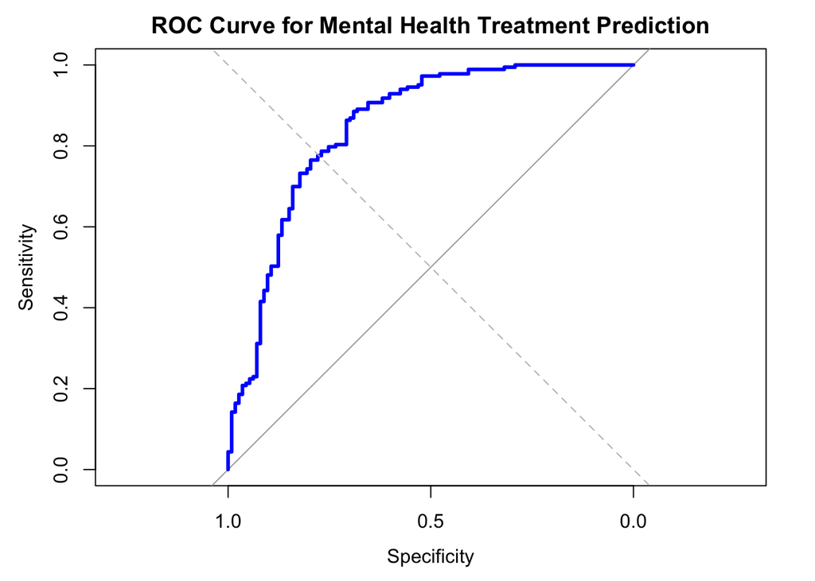

```r
plot(roc_curve, main="ROC Curve for Mental Health Treatment Prediction", col="blue", lwd=3)
abline(a=0, b=1, col="grey", lty=2)
```

#### Prediction (training set)

- Strength of model:  
  **High Specificity (91.91%)**: Excellent at identifying people who truly need treatment  
  **Good Overall Accuracy (80.23%)**: Beats baseline by 16 percentage points  
  **Balanced Precision**: Similar precision for both classes (~80%)  
  **Statistical Significance**: Results are not due to chance
- Concerns  
  **Low Sensitivity (59.27%)**: Poor at identifying people who don’t need treatment  
  **Imbalanced Performance**: Much better at detecting treatment needs than non-needs  
  **Potential Over-intervention**: 40.73% of “No treatment” people are incorrectly flagged

```r
train_data$predicted_prob <- predict(logit_model, type="response")
train_data$predicted_class <- ifelse(train_data$predicted_prob > 0.5, 1, 0)
train_conf <- confusionMatrix(as.factor(train_data$predicted_class), as.factor(train_data$treatment_binary))
print(train_conf)
```

```
## Confusion Matrix and Statistics
##
##           Reference
## Prediction   0   1
##          0 147  36
##          1 101 409
##
##                Accuracy : 0.8023
##                  95% CI : (0.7707, 0.8313)
##     No Information Rate : 0.6421
##     P-Value [Acc > NIR] : < 2.2e-16
##
##                   Kappa : 0.5434
##
##  Mcnemar's Test P-Value : 4.554e-08
##
##             Sensitivity : 0.5927
##             Specificity : 0.9191
##          Pos Pred Value : 0.8033
##          Neg Pred Value : 0.8020
##              Prevalence : 0.3579
##          Detection Rate : 0.2121
##    Detection Prevalence : 0.2641
##       Balanced Accuracy : 0.7559
##
##        'Positive' Class : 0
##
```

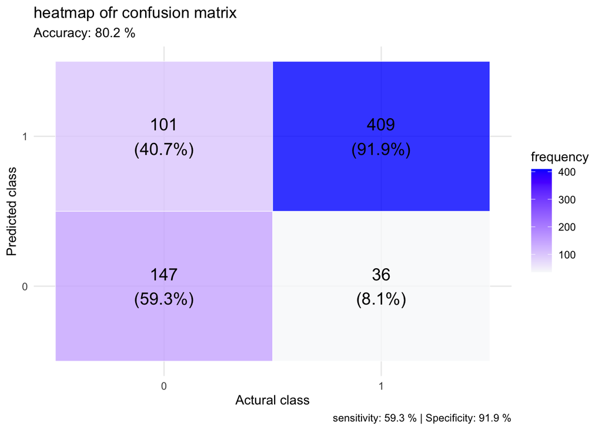

```r
# vusualize confusion data
conf_matrix_data <- as.data.frame(as.table(train_conf$table))
names(conf_matrix_data) <- c("Predicted", "Actual", "Freq")

# calculate relevant statistics
conf_matrix_data <- conf_matrix_data %>%
  group_by(Actual) %>%
  mutate(
    Percentage = Freq / sum(Freq) * 100,
    Label = paste0(Freq, "\n(", round(Percentage, 1), "%)")
  )

# plot heatmap ofr confusion matrix
ggplot(conf_matrix_data, aes(x = Actual, y = Predicted, fill = Freq)) +
  geom_tile(color = "white", alpha = 0.8) +
  geom_text(aes(label = Label), color = "black", size = 5) +
  scale_fill_gradient(low = "#F8F9FA", high = "blue", name = "frequency") +
  labs(
    title = "heatmap ofr confusion matrix",
    subtitle = paste("Accuracy:", round(train_conf$overall["Accuracy"]*100, 1), "%"),
    x = "Actural class",
    y = "Predicted class",
    caption = paste("sensitivity:", round(train_conf$byClass["Sensitivity"]*100, 1), "% |",
                   "Specificity:", round(train_conf$byClass["Specificity"]*100, 1), "%")
  ) +
  theme_minimal()
```

## **6. Answering data science questions**

### 6.2 What could employers do to reduce mental issue’s risks?

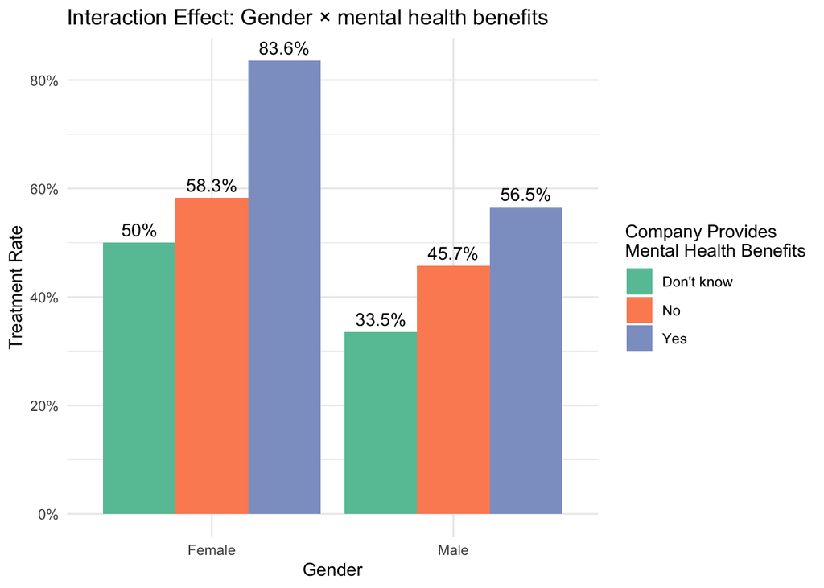

```r
# 1. Interaction Effects Visualization - benefit * Gender
gender_care_data <- survey_clean0 |>
  filter(Gender!="Transgender/Non-binary/Others")|>
  mutate(
    treatment_binary = ifelse(treatment == "Yes", 1, 0)
  )|>
  group_by(Gender, benefits) |>
  summarise(
    treatment_rate = mean(treatment_binary),
    n = n(),
    .groups = 'drop'
  )

ggplot(gender_care_data, aes(x = Gender, y = treatment_rate, fill = benefits)) +
  geom_bar(stat = "identity", position = "dodge") +
  geom_text(aes(label = paste0(round(treatment_rate*100, 1), "%")),
            position = position_dodge(width = 0.9), vjust = -0.5) +
  labs(
    title = "Interaction Effect: Gender × mental health benefits",
    x = "Gender",
    y = "Treatment Rate",
    fill = "Company Provides\nMental Health Benefits"
  ) +
  theme_minimal() +
  scale_y_continuous(labels = scales::percent) +
  scale_fill_brewer(palette = "Set2")
```

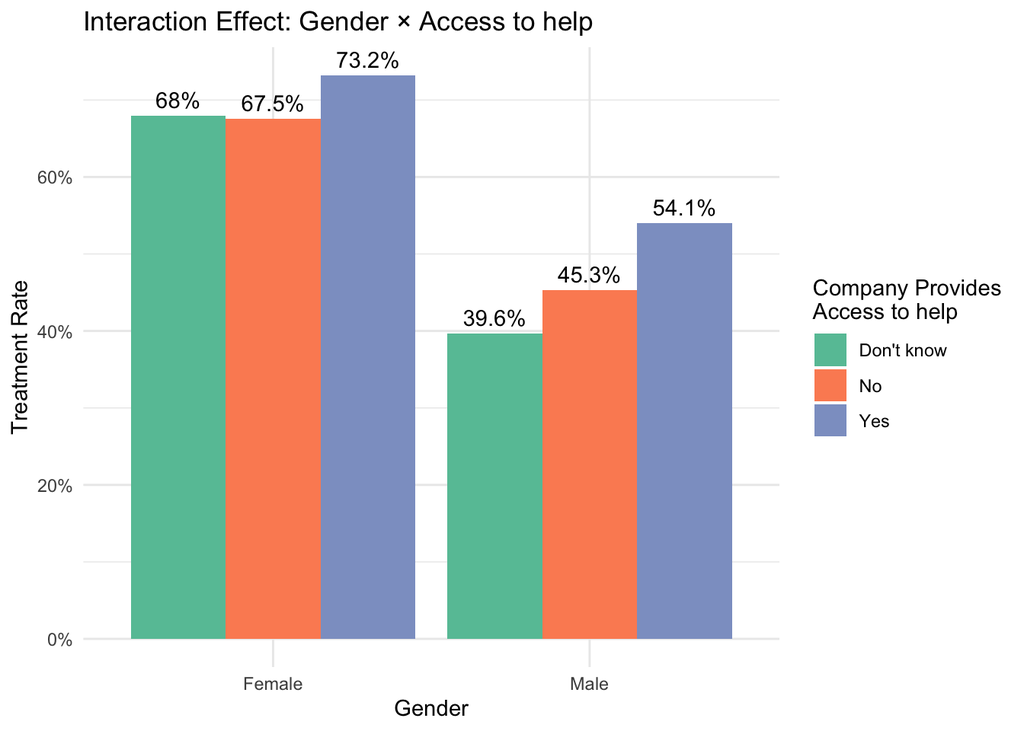

```r
# 2. Interaction Effects Visualization - seek_help * Gender
gender_care_data <- survey_clean0 |>
  filter(Gender!="Transgender/Non-binary/Others")|>
  mutate(
    treatment_binary = ifelse(treatment == "Yes", 1, 0)
  )|>
  group_by(Gender, seek_help) |>
  summarise(
    treatment_rate = mean(treatment_binary),
    n = n(),
    .groups = 'drop'
  )

ggplot(gender_care_data, aes(x = Gender, y = treatment_rate, fill = seek_help)) +
  geom_bar(stat = "identity", position = "dodge") +
  geom_text(aes(label = paste0(round(treatment_rate*100, 1), "%")),
            position = position_dodge(width = 0.9), vjust = -0.5) +
  labs(
    title = "Interaction Effect: Gender × Access to help",
    x = "Gender",
    y = "Treatment Rate",
    fill = "Company Provides\nAccess to help"
  ) +
  theme_minimal() +
  scale_y_continuous(labels = scales::percent) +
  scale_fill_brewer(palette = "Set2")
```

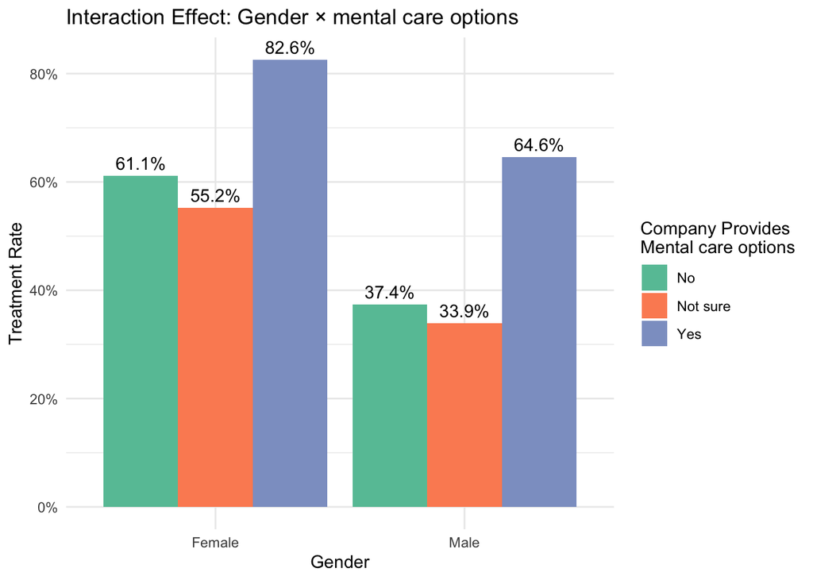

```r
# 3. Interaction Effects Visualization - care_options * Gender
gender_care_data <- survey_clean0 |>
  filter(Gender!="Transgender/Non-binary/Others")|>
  mutate(
    treatment_binary = ifelse(treatment == "Yes", 1, 0)
  )|>
  group_by(Gender, care_options) |>
  summarise(
    treatment_rate = mean(treatment_binary),
    n = n(),
    .groups = 'drop'
  )

ggplot(gender_care_data, aes(x = Gender, y = treatment_rate, fill = care_options)) +
  geom_bar(stat = "identity", position = "dodge") +
  geom_text(aes(label = paste0(round(treatment_rate*100, 1), "%")),
            position = position_dodge(width = 0.9), vjust = -0.5) +
  labs(
    title = "Interaction Effect: Gender × mental care options",
    x = "Gender",
    y = "Treatment Rate",
    fill = "Company Provides\nMental care options"
  ) +
  theme_minimal() +
  scale_y_continuous(labels = scales::percent) +
  scale_fill_brewer(palette = "Set2")
```